# Práctica Tema 6

Álvaro Miranda García

2023-03-27

**1. Instale y cargue las siguientes librerías: “MASS”, “caret”, “stat”, “olsrr”, “kable”, “kableExtra”, “knitr” y “rmarkdown”**

Han sido instaladas.

**2. Cree 2 variables almacenadas como vector: “y_cuentas” y “x_distancia” a partir de los siguientes valores numéricos:**

```r
y_cuentas = c(110,2,6,98,40,94,31,5,8,10)
x_distancia = c(1.1,100.2,90.3,5.4,57.5,6.6,34.7,65.8,57.9,86.1)
```

**3. Verifique el supuesto de linealidad de la variable explicativa incluyendo un contraste de hipótesis.**

```r
modelo <- lm(y_cuentas ~ x_distancia)
anova(modelo)
```

```
## Analysis of Variance Table
##
## Response: y_cuentas
##             Df  Sum Sq Mean Sq F value    Pr(>F)
## x_distancia  1 14552.3   14552  47.399 0.0001265 ***
## Residuals    8  2456.1     307
## ---
## Signif. codes:  0 '***' 0.001 '**' 0.01 '*' 0.05 '.' 0.1 ' ' 1
```

**4. Verifique el supuesto de normalidad de la variable explicativa mediante su visualización en un histograma y un test de normalidad.**

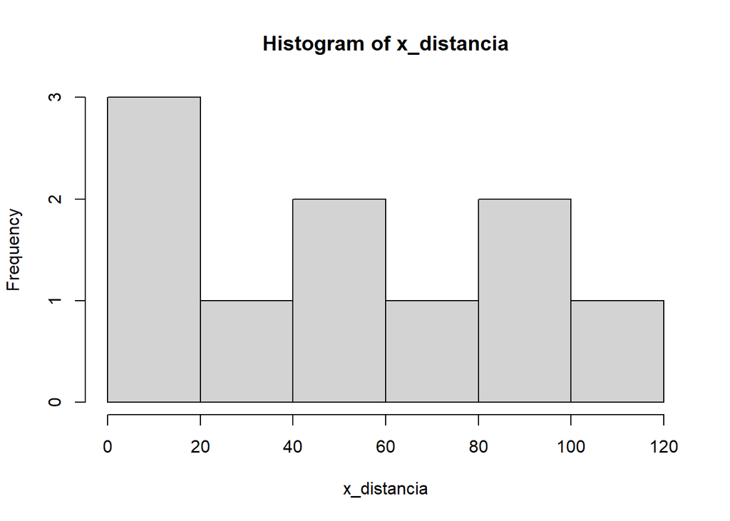

```r
hist(x_distancia)
```

```r
shapiro.test(x_distancia)
```

```
##
##  Shapiro-Wilk normality test
##
## data:  x_distancia
## W = 0.90687, p-value = 0.2602
```

**5. Multiplique las variable de respuesta por la variable explicativa. Llama al objeto “xy”.**

```r
xy = y_cuentas * x_distancia
xy
```

```
##  [1]  121.0  200.4  541.8  529.2 2300.0  620.4 1075.7  329.0  463.2  861.0
```

**6. Eleve al cuadrado la variable explicativa. Llama al objeto “x_cuadrado”.**

```r
x_cuadrado <- x_distancia^2

x_cuadrado
```

```
##  [1]     1.21 10040.04  8154.09    29.16  3306.25    43.56  1204.09  4329.64
##  [9]  3352.41  7413.21
```

**7. A continuación, almacena las variables: “y_cuentas”, “x_distancia”, “xy” y “x_cuadrado” en un data frame llamado “tabla_datos”**

```r
tabla_datos <- data.frame(y_cuentas, x_distancia, xy, x_cuadrado)
```

**8. Visualice el objeto “tabla_datos” en una tabla en la consola a través de alguna de las funciones ofrecidas por la librería “kableExtra”.**

```r
library(kableExtra)
kable(tabla_datos, caption = "Tabla de Datos") %>%
  kable_styling(full_width = F)
```

Tabla de Datos

| y_cuentas | x_distancia | xy | x_cuadrado |
| --- | --- | --- | --- |
| 110 | 1.1 | 121.0 | 1.21 |
| 2 | 100.2 | 200.4 | 10040.04 |
| 6 | 90.3 | 541.8 | 8154.09 |
| 98 | 5.4 | 529.2 | 29.16 |
| 40 | 57.5 | 2300.0 | 3306.25 |
| 94 | 6.6 | 620.4 | 43.56 |
| 31 | 34.7 | 1075.7 | 1204.09 |
| 5 | 65.8 | 329.0 | 4329.64 |
| 8 | 57.9 | 463.2 | 3352.41 |
| 10 | 86.1 | 861.0 | 7413.21 |

**9. Realice el sumatorio de los valores almacenados en las 4 columnas del data frame “tabla_datos”.**

```r
#primer sumatorio

sum1 = sum (tabla_datos$y_cuentas)

#segundo sumatorio

sum2 =  (tabla_datos$x_distancia)

#tercer sumatorio

sum3 = (tabla_datos$xy)

#cuarto sumatorio

sum4 = (tabla_datos$x_cuadrado)
```

**10. Añada el sumatorio de las 4 columnas como un último registro en el data frame “tabla_datos” de modo que tengamos en un solo objeto los valores junto con el sumatorio.**

```r
sum.y_cuentas <- sum(tabla_datos$y_cuentas)
sum.x_distancia <- sum(tabla_datos$x_distancia)
sum.xy <- sum(tabla_datos$xy)
sum.x_cuadrado <- sum(tabla_datos$x_cuadrado)

row.sums <- c(sum.y_cuentas,sum.x_distancia,sum.xy,sum.x_cuadrado)

tabla_datos_final <- rbind(tabla_datos, row.sums)

tabla_datos_final
```

```
##    y_cuentas x_distancia     xy x_cuadrado
## 1        110         1.1  121.0       1.21
## 2          2       100.2  200.4   10040.04
## 3          6        90.3  541.8    8154.09
## 4         98         5.4  529.2      29.16
## 5         40        57.5 2300.0    3306.25
## 6         94         6.6  620.4      43.56
## 7         31        34.7 1075.7    1204.09
## 8          5        65.8  329.0    4329.64
## 9          8        57.9  463.2    3352.41
## 10        10        86.1  861.0    7413.21
## 11       404       505.6 7041.7   37873.66
```

$$\begin{equation}
\sigma^2 = \frac{\sum\limits_{i=1}^{n}(y_i – \bar{y})^2} {n – 1}
\end{equation}$$

**11. Calcule la recta de regresión por el método de mínimos cuadrados (ordinario) a través de los datos incluidos en el data frame “tabla_datos”.**

```r
modelo <- lm(y_cuentas ~ x_distancia)
```

**12. Visualice en un gráfico de dispersión la recta de regresión, nube de puntos. Indique en el título la ecuación resultante y edite los nombre de los ejes.**

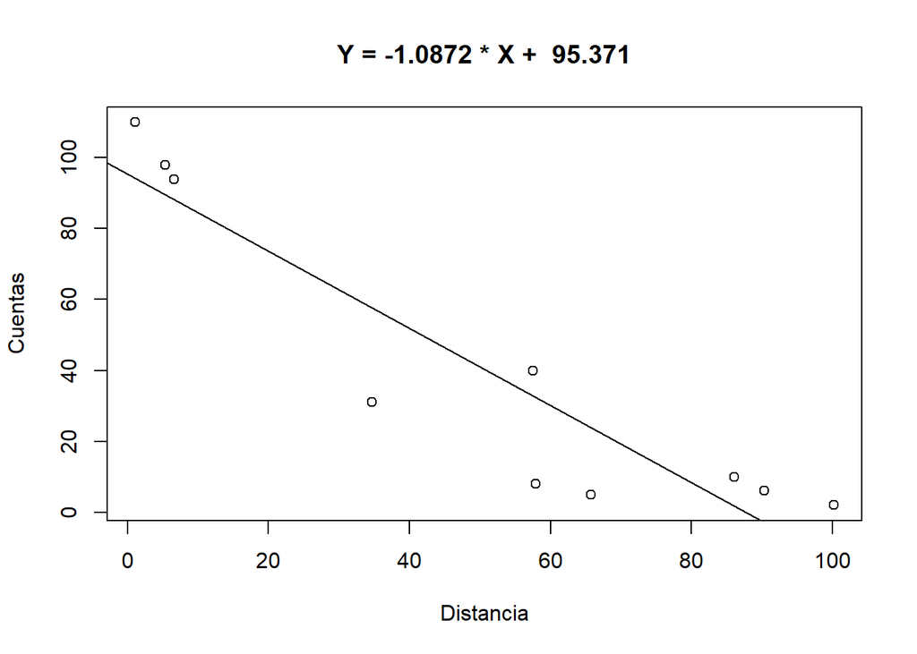

```r
plot(x_distancia, y_cuentas, main = paste("Y =", round(modelo$coefficients[2],4),"* X + ", round(modelo$coefficients[1],4)), xlab = "Distancia", ylab = "Cuentas")
abline(modelo)
```

**13. Calcule los residuos, residuos estandarizados y residuos estudentizados del modelo recién ajustado.**

```r
residuos <- resid(modelo)
residuos
```

```
##          1          2          3          4          5          6          7
##  15.824925  15.570779   8.807066   8.500073   7.145471   5.804766 -26.643686
##          8          9         10
## -18.830406 -24.419631   8.240642
```

```r
residuos_estandarizados <- rstandard(modelo)
residuos_estandarizados
```

```
##          1          2          3          4          5          6          7
##  1.0784816  1.0622593  0.5721649  0.5661008  0.4307982  0.3843280 -1.6213545
##          8          9         10
## -1.1448722 -1.4726329  0.5266739
```

```r
residuos_estudentizados <- rstudent(modelo)
residuos_estudentizados
```

```
##          1          2          3          4          5          6          7
##  1.0912716  1.0721374  0.5465101  0.5404749  0.4077319  0.3628715 -1.8509341
##          8          9         10
## -1.1711614 -1.6134626  0.5014281
```

**14. Calcula el pronóstico o estimación del modelo para una observación que registra una distancia de 6.6km con respecto a la mina.**

```r
predict(modelo, newdata = data.frame(x_distancia = 6.6))
```

```
##        1
## 88.19523
```

$$\begin{equation}
Y_i = \beta_0 + \beta_1 X_i + \epsilon_i
\end{equation}$$

**15. Genera dos conjuntos aleatorios de datos: “entrenamiento” y “validación”**

```r
set.seed(12345)
entrenamiento <- sample(1:nrow(tabla_datos), 0.7*nrow(tabla_datos))
validacion <- setdiff(1:nrow(tabla_datos), entrenamiento)
```

**16. Ajusta nuevamente el modelo con el conjunto de “entrenamiento”.**

```r
modelo_entrenamiento <- lm(y_cuentas ~ x_distancia, data = tabla_datos, subset = entrenamiento)
```

**17. Interprete el valor asociado a los coeficientes de regresión y a R2. ¿Qué significan los asteriscos inmediatamente a la derecha de los valores arrojados tras ajustar el modelo?**

```r
summary(modelo_entrenamiento)
```

```
##
## Call:
## lm(formula = y_cuentas ~ x_distancia, data = tabla_datos, subset = entrenamiento)
##
## Residuals:
##        3        8        2        5       10        9        7
##   0.3291 -11.6053   0.7475  19.6904   2.4546 -12.1311   0.5148
##
## Coefficients:
##             Estimate Std. Error t value Pr(>|t|)
## (Intercept)  45.9719    15.2326   3.018   0.0295 *
## x_distancia  -0.4463     0.2073  -2.153   0.0839 .
## ---
## Signif. codes:  0 '***' 0.001 '**' 0.01 '*' 0.05 '.' 0.1 ' ' 1
##
## Residual standard error: 11.63 on 5 degrees of freedom
## Multiple R-squared:  0.4811, Adjusted R-squared:  0.3773
## F-statistic: 4.636 on 1 and 5 DF,  p-value: 0.08392
```

Los asteriscos significan que el coeficiente de regresión es significativo estadísticamente para un nivel de significación del 5%.

**18. ¿Cómo se ha realizado el cálculo para los grados de libertad del modelo?**